# PCA_METEOROLOGÍA

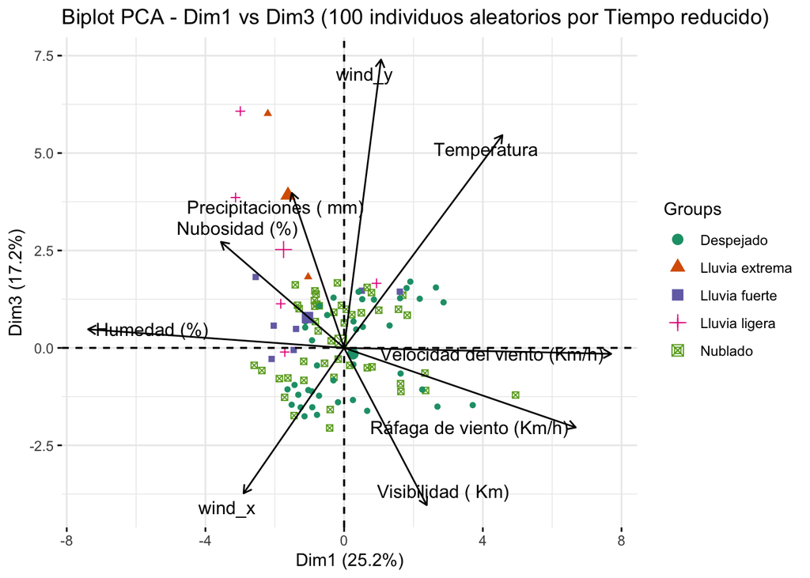

```r
# Seleccionar 100 individuos al azar
set.seed(123)
ind_sel <- sample(1:nrow(df_pca), 100)

# Biplot en Dim2 vs Dim4 con colores por Tiempo_reducido
fviz_pca_biplot(res.pca,
                axes = c(1, 3),
                select.ind = list(name = ind_sel),
                habillage = df_pca$Tiempo_reducido,
                addEllipses = FALSE,
                palette = "Dark2",
                col.var = "black",
                label = "var",
                repel = TRUE,
                title = "Biplot PCA - Dim1 vs Dim3 (100 individuos aleatorios por Tiempo reducido)")
```

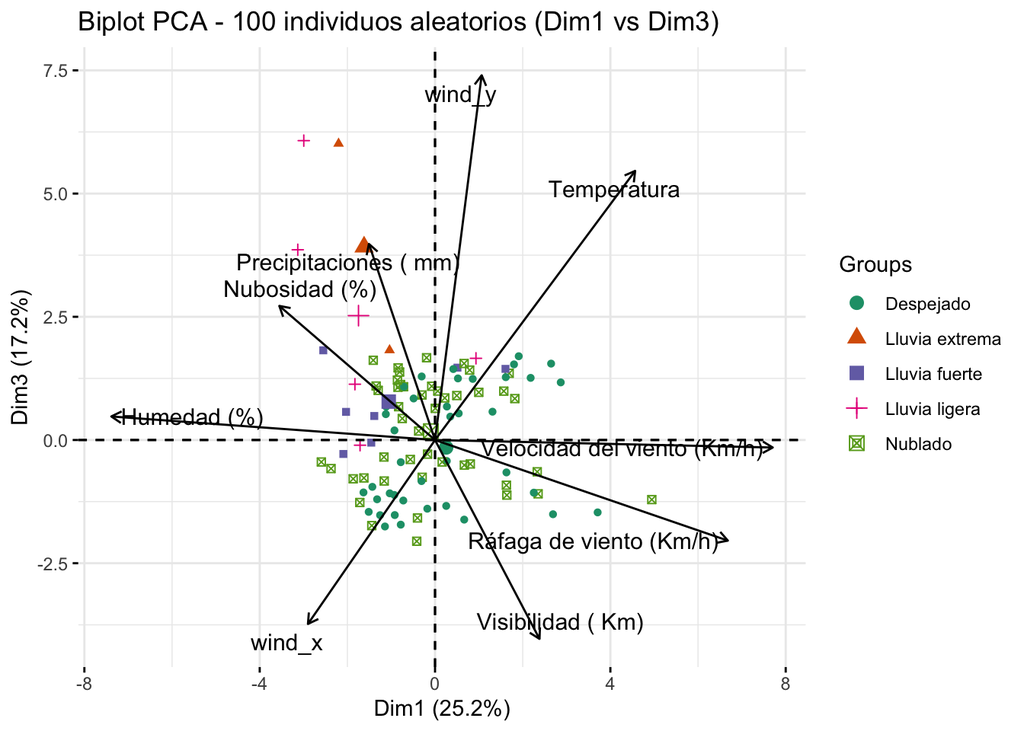

```r
# Biplot con 100 individuos aleatorios (Dim1 vs Dim3)
fviz_pca_biplot(res.pca,
                axes = c(1, 3),
                select.ind = list(name = ind_sel),
                habillage = df_pca$Tiempo_reducido,
                addEllipses = FALSE,
                palette = "Dark2",
                col.var = "black",
                label = "var",
                repel = TRUE,
                title = "Biplot PCA - 100 individuos aleatorios (Dim1 vs Dim3)")
```

A nivel de distribución de grupos, no se observan separaciones nítidas: las categorías Despejado, Nublado y Lluvia ligera se solapan notablemente. Esto confirma que Dim3 no contribuye significativamente a la discriminación entre las clases de tiempo reducido, aunque sí aporta información valiosa sobre la interacción entre temperatura y orientación del viento. En resumen, este gráfico complementa la interpretación del PCA mostrando que aunque Dim1 sigue explicando bien la intensidad del viento y condiciones térmicas, Dim3 permite capturar mejor la influencia direccional del viento. No obstante, la mezcla entre individuos sugiere que estas dimensiones no son las más eficaces para clasificar observaciones según categorías climáticas generales, pero sí para explorar matices meteorológicos más específicos.

```
## Too few points to calculate an ellipse
```

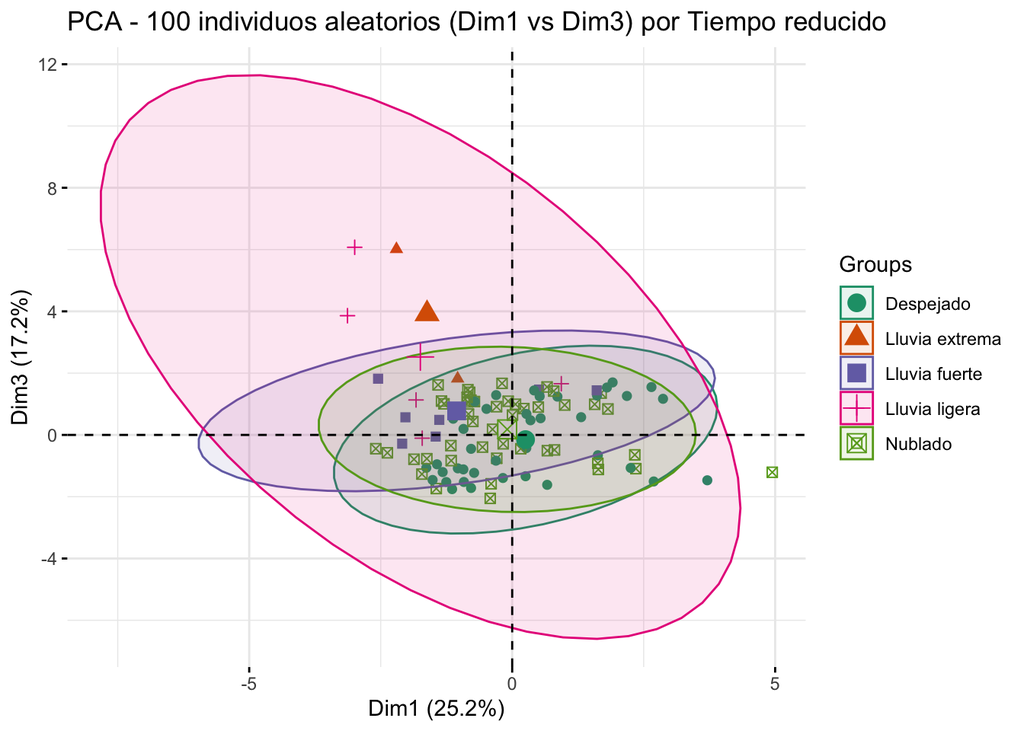

```r
# Gráfico de solo individuos con elipses (Dim1 vs Dim3)
fviz_pca_ind(res.pca,
             axes = c(1, 3),
             select.ind = list(name = ind_sel),
             habillage = df_pca$Tiempo_reducido,
             addEllipses = TRUE,
             palette = "Dark2",
             pointsize = 2,
             label = "none",
             title = "PCA - 100 individuos aleatorios (Dim1 vs Dim3) por Tiempo reducido")
```

Como se comentó anteriormente, en la tercera dimensión los individuos tienden a solaparse en mayor medida, algo que se aprecia claramente en este gráfico.